# CEE306 Hydrology: Water and Climate

## HW3: Groundwater

**Name:** `<Sayfullo Saidov>`

## Overview

Groundwater makes up the Earth's largest available store of freshwater, by far. It's defined as subsurface water where the soil pores are completely *saturated*. The area between the water table and the surface where there are varying degrees of saturation is called the vadose (or *unsaturated*) zone.

This notebook first goes through a quick review of different properties of soil moisture and aquifers, then leads into an intro to the ParFlow Sandtank. From there, we will look at Darcy's law and utilize the Dupuit approximation for different situations and assumptions, such as unconfined flow and drainage to streams. Lastly, we will integrate the linear reservoir model into the groundwater equations.

```python
# import packages
import pandas as pd
import matplotlib.pyplot as plt
import numpy as np
```

## 1. Soil and Aquifer Properties

### Soil Properties

Before getting into groundwater, we can define some basic soil properties, all functions of the volumetric fraction of water, soil, and air space, represented by $V_{water}$, $V_{soil}$, and $V_{air}$, respectively. The total volume, $V_{total}$ is the sum of these three. It is also common to see $V_{water}$ and $V_{air}$ summed into one term, $V_{voids}$, which stands for the volumetric ratio of any void space: $$ V_{total} = V_{soil} + V_{water} + V_{air} = V_{soil} + V_{voids} $$

*Soil porosity*, $n$, is the total volume occupied by pore space per unit volume of soil and is a dimensionless quantity, $$ n = 1 - \frac{V_{soil}}{V_{total}} = \frac{V_{water} + V_{air}}{V_{total}} = \frac{V_{voids}}{V_{total}} $$ which is essentially an upper bound on how much water that soil can hold. The amount of water in the soil is the *soil water content*, defined as $$ \theta = \frac{V_{water}}{V_{total}}\ $$

The *saturation*, $\theta^*$, is thus defined as $$ \theta^* = \frac{\theta}{n} = \frac{V_{water}}{V_{water} + V_{air}} $$ which has an upper limit of 1, when the soil is completely saturated.

Here are some properties of an example soil:

```python
# define volumetric fractions of water, soil, and pore space
V_water = 0.22
V_soil = 0.58
V_air = 0.31
V_total = V_water + V_soil + V_air

# calculate soil porosity
n = 1 - V_soil/V_total

# calculate soil water content
theta = V_water/V_total

# calculate saturation
theta_star = theta/n

# print statements
print(f'Soil porosity:  {n:.2f}')
print(f'Soil water content:  {theta:.2f}')
print(f'Saturation:  {theta_star:.2f}')
```

```
Soil porosity:  0.48
Soil water content:  0.20
Saturation:  0.42
```

### Aquifer Properties

The soil properties defined above are useful for volumes, but hydrologists tend to talk about fluid at a point, using the *total hydraulic head* $h$, with dimensions of length [L]. The total hydraulic head is the total potential energy per unit weight of a fluid at a point; the sum of the *gravitational head*, $z$ [L] and the *pressure head*, $\psi$ [L].

The gravitational head $z$ is simply the elevation of the measured point above an arbitrary datum, while $\psi$ is the fluid's gauge pressure $p$ [F/L$^2$] divided by the fluid's density $\gamma$ [F/L$^3$]:

$$ h = z + \psi = z + \frac{p}{\gamma} $$

*Aquifers* are geological formations that can store enough water and transmit it at a rate fast enough to be hydrologically significant.There are two major classes of aquifers:

1. *Unconfined aquifer*: an aquifer where the upper boundary of the water table is at atmospheric pressure. At atmospheric pressure, the gauge pressure $p=0$, so the total hydraulic head is simply $h=z$. Recharge usually occurs via percolation, increasing the elevation of the water table (thus flow and storage are correlated).
2. *Confined aquifer*: an aquifer where the upper boundary of the water table is confined by a geologic formation with a significantly lower hydraulic conductivity. If the geologic barrier was not present, the "water level" in the aquifer might be higher. In this case, the pressure is greater than atmospheric. Recharge usually occurs through infiltration at an area where the flow is not confined.

##### Aquifer Storage

As one can imagine, these two aquifers differ in the *volume of water stored* and *changes in response to variations in total head ($h$)*. This is measured with *storativity*, or the *storage coefficient* ($S$), a dimensionless coefficient defined as the volume of water released from storage per unit decline in hydraulic head in the aquifer, per unit area of the aquifer. $$ S = \frac{(\text{volume of water entering/leaving control volume})}{(\text{increase or decrease in head})\times Area} $$

$S$ is determined based on the type of aquifer. In *confined* aquifers: $$ S = S_sb $$ where $S_s$ is the specific storage, or the volume of water released per unit volume of aquifer per unit decline of water table [L$^{-1}$], and $b$ is the aquifer thickness [L]. In *unconfined* aquifers:

$$ S = S_y $$

where $S_y$ is the specific yield, or the ratio of the water volume that drains by gravity from a sample to the total volume of rock or soil [-]. It is also known as the drainable porosity.

##### Groundwater Movement

The ease with which water can move through an aquifer is defined by the *hydraulic conductivity* coefficient ($K$) [LT$^{-1}$]. The value of $K$ varies depending on the type of medium within a geologic unit. For example, $K$ will be lower for clay than for sand.

We use this coefficient in the Darcy equation, which describes the fluid flow through a porous medium. Flow is determined by multiplying hydraulic conductivity $K$ by the hydraulic gradient $\frac{dh}{dl}$, or the change in total hydraulic head divided by the distance in which this change occurs: $$ q = \frac{Q}{A} = -K\frac{dh}{dl} $$
where $q$, the specific discharge [LT$^{-1}$], is equal to $Q/A$, the volumetric flow rate divided by the cross-sectional area. Hydraulic gradient is the force that causes groundwater to move in the direction of decreasing total hydraulic head.

## 2. ParFlow Sandtank

[ParFlow](https://parflow.org) is a powerful tool that models surface and subsurface flow. This software is the foundation of the [Sandtank](https://sandtank.hydroframe.org) we will be using, a virtual representation of a physical tool that helps teach groundwater flow processes. Like with a physical sandtank model, you will see a 2-dimensional box that represents a section of the earth, with deposits of different geological layers beneath some surface topography. On the sides, there are columns that can be filled with water. The amount of water on each side and the distribution of material in the middle will dictate how water flows in the subsurface.

### Quick Guide to Sandtank

- The **life preserver** icon in the top left brings you to the user manual.
- On the top ribbon is the **run** button which runs the model, implementing any changes you have made to the conditions.
- When running the model, the counter next to the **clock** icon will increase. You will likely see changes with multiple hits of the **run** button without changing any conditions.
- The **blue columns** on the left and right side of the model are the hydraulic heads at the boundary. You can adjust this up and down by clicking or dragging.
- There are **wells** along the model with counters above them that can either pump water out, inject water in, or be closed off.
- The **River/Lake** option at the top of the screen toggles the big divot from behaving as a river or as a lake.
- In the top left is a three-bar icon that brings up many **model options**
- Clicking the three-bar icon in the upper left-hand corner allows you to toggle the **visibility** of soil, water, wells, still water, and pollutant (pollutant can be injected from the wells).
- Scrolling to the bottom, you can see that the sandtank is modeled with numbered **geological deposits**. You can adjust the **material properties** of each deposit with the sliders from a range of clay, loam, sand, and gravel.

Take a few minutes and expierment with Sandtank.

## 3. Darcy's Law and the Dupuit Approximation

As mentioned above, the basics of groundwater flow are best described by **Darcy's Law**. Consider a one directional velocity in the $x$ direction, say the *Darcy velocity* $q_x$ with dimensions in [L T$^{-1}$]. This velocity moves downhill in regards to total head $h$, and is proportional to the local hydraulic conductivity, $K_{hx}$: $$ q_x=-K_{hx}\frac{\text{d}h}{\text{d}x} $$

Quick note: we mentioned above that the Darcy velocity $q_x$ is simply the volumetric flow rate $Q_x$ divided by the cross-sectional area $A_x$ of the medium the water is flowing in. This law is valid for *laminar flow*.

(From Dingman V3 Box 9.3)

To get to the equation of flow in a simplified aquifer, we will start with mass conservation, which at its simplest form, for some storage $s$, is $$ \Delta m = m_{in} - m_{out} $$ where each term has dimenions of [M]. We will use the following variables to define these flows:

- Darcy velocities in the x and y direction: $q_x$ and $q_y$ [L T$^{-1}$]
- Net rate of recharge from infiltration: $R_I$ [L T$^{-1}$]
- Hydraulic head: $h$ [L]

Consider the following assumptions for Darcy flow:

[figure not shown]

_Figure 1 (from Dingman): Definition diagram for the derivation of the Dupuit equation. Assumptions: (1) the control volume extends from a horizontal impermeable base in the $x$-$y$ plane up to the water table, (2) at any point $(x,y)$, the total head $h$ is constant in the vertical, such that the vertical flow rate $q_z=0$, (3) the head gradients equal the slope of the water table._

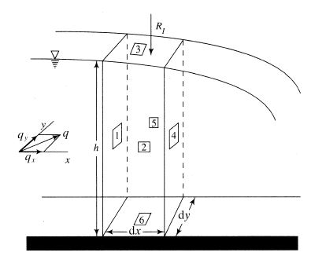

### Dupuit Approximation Example in Python

Let's further assume we are only looking in the x-direction, and $R_I=0$. This simplifies our equation to a nonlinear PDE (partial differential equation), $$ \frac{\partial^2(h^2)}{\partial x^2} = \frac{2S_Y}{K_h} \frac{\partial h}{\partial t} $$ where $h$ is now just a function of $x$ and $t$. This equation could be solved numerically. However, given a function for the head's initial condition, $h(x,t=0)$, we can solve for the next timestep using the derivative of $h(x,t=0)^2$, essentially combining the analytical and numerical methods of solving PDEs.

Keep in mind this is just for demonstrational purposes, there are no equations here for the conservation of water, which would have to be included if this were a closed system.

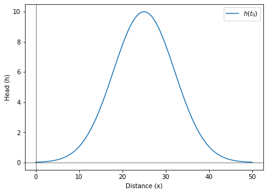

```python
# example - some unrealistic initial conditions
# assume that R_I=0, we are only looking in the x-direction, and K_h=S_y=1
# the head on the left and right are approx 0

# initial distribution of water (bell curve)
x = np.linspace(0,50,100)
h_0 = 10*np.exp(-((x-25)/10)**2)

# see what this looks like
fig, ax = plt.subplots(figsize=(7,5))
ax.plot(x, h_0, label=r'$h(t_0)$')
ax.set_xlabel("Distance (x)")
ax.set_ylabel("Head (h)")
ax.axhline(y=0,color='k',linewidth=0.5)
ax.axvline(x=0,color='k',linewidth=0.5)
ax.legend()
```

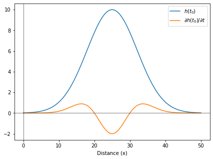

```python
# set values of hydraulic conductivity (K_h) and specific yield (S_y)
K_h = 1.0
S_y = 1.0

# now let's approximate dh/dt using the second derivative of h^2
d2h2_dt2 = (4/25)*np.exp(-(1/50)*(x-25)**2)*(x**2-50*x+600)
# found using wolframalpha.com

# complete the left-hand side to calculate dh/dt
dh_dt = (K_h/(2*S_y))*d2h2_dt2

# see what this looks like
fig, ax = plt.subplots(figsize=(7,5))
ax.plot(x, h_0, label=r'$h(t_0)$')
ax.plot(x, dh_dt, label=r'$\partial h(t_0) / \partial t$')
ax.axhline(y=0,color='k',linewidth=0.5)
ax.axvline(x=0,color='k',linewidth=0.5)
ax.set_xlabel("Distance (x)")
ax.legend()
```

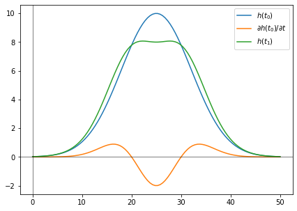

```python
# lastly, find h at the next timestep by adding the approximation of dh/dt
h_1 = h_0 + dh_dt

# see what this looks like
fig, ax = plt.subplots(figsize=(7,5))
ax.plot(x, h_0, label=r'$h(t_0)$')
ax.plot(x, dh_dt, label=r'$\partial h(t_0) / \partial t$')
ax.plot(x, h_1, label=r'$h(t_1)$')
ax.axhline(y=0,color='k',linewidth=0.5)
ax.axvline(x=0,color='k',linewidth=0.5)
ax.legend()
```

Going through this process again would entail taking the second derivative of $h_1(x,t)^2$, where $h_1(x,t)$ already has the second derivative of $h_0(x,t)^2$, so you can see how even doing the second step in this process is quite tedious. Running this system for anything longer than one timestep would probably require a numerical solution.

### Dupuit Approximation for Steady-State Unconfined Aquifer Drainage to Streams

(Dingman V3 Box 9.4)

Here, we make even more assumptions for aquifer drainage to streams. A steady state assumption says that the process of interest (in this case, hydraulic head) is not changing in time (this assumption is made a lot for long-term averages). In terms of equations, this means any term with a derivative of $h$ with respect to time is now equal to zero. We can also look only in the $x$-direction, leading to $$ \frac{2\cdot R_I}{K_h}+\frac{\partial^2(h^2)}{\partial x^2} = 0 $$ From here, we can solve analytically for $h^2$ by performing separation of variables, obtaining $$ h^2=-\frac{R_I}{K_h} x^2 + C_1x + C_2 $$

From here, we need to solve for $C_1$ and $C_2$. Let's assume an asymmetrical situation so that the hydraulic head on the left at $h(x=0)=h_0$, and the hydraulic head on the right $h(x=X) = h_X$ (where $X$ is the length of the aquifer). See the diagram below. In Sandtank, there would be the left and right blue sliders. After solving for $C_1$ and $C_2$, we obtain $$ h^2 = -\frac{R_I}{K_h} x^2 + x\bigg(\frac{h_X^2-h_0^2}{X} + \frac{R_I X}{K_h}\bigg) + h_0^2 $$

See this diagram:

[figure not shown]

_Figure 2 (from Dingman): Definition sketch for Dupuit flow to streams. $h_0$ is the head of the stream on the left, and $h_X$ is the head of the stream on the right._

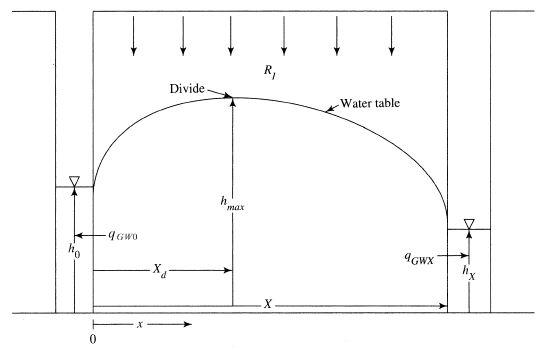

### Unconfined Aquifer Drainage Example in Python

We can use these above equations, as messy as they are, to visualize the steady-state water table position.

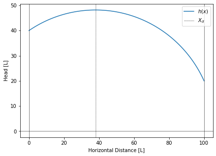

```python
# set parameters: h_0 (left end), h_X (right end), X (spacing between streams), R_I, and K_h
h_0 = 40.0
h_X = 20.0
X = 100.0
R_I = 1.0
K_h = 2.0

# create mesh based on length between streams
x = np.linspace(0,X,100)

# define function to calculate h
def h(x):
    return np.sqrt(-(R_I/K_h)*x**2 + x*(((h_X**2 - h_0**2)/X) + (R_I*X/K_h)) + h_0**2)

# define function to calculate X_d and h_max (steady state infiltration)
def ss_infiltration(h_0, h_X, X, R_I, K_h):

    # note that all of these parameters are defined above as global variables
    # but you could change anytime you call the equation

    # calculate X_d (local variables)
    X_d_local = 0.5*X - (K_h*(h_0**2.0 - h_X**2.0))/(2*R_I*X)

    # calculate h_max (a local variable using h defined above, a global function)
    h_max_local = h(X_d_local)

    # return both values
    return X_d_local, h_max_local

# call the function
X_d, h_max = ss_infiltration(h_0, h_X, X, R_I, K_h)

# plot
fig, ax = plt.subplots(figsize=(7,5))
ax.plot(x,h(x),label=r'$h(x)$')
# plot vertical and horizontal lines
ax.axvline(x=0,color='k',linewidth=0.5)
ax.axvline(x=X,color='k',linewidth=0.5)
ax.axvline(x=X_d, color = 'k',linewidth=0.5, linestyle='dashed',label=r'$X_d$')
ax.axhline(y=0, color='k', linewidth=0.5)
ax.set_ylabel('Head [L]')
ax.set_xlabel('Horizontal Distance [L]')
ax.legend(loc='upper right')
```

Remember that this is a steady-state picture, so in the above plot, infiltration is happening *consistently* along the aquifer. Everything left of the dotted line is flowing to the left, and everything right of the dotted line is flowing to the right.

## 4. Drainage of a Linear-Reservoir Aquifer

A **well hydrograph** is a series of hydraulic head measurements in a groundwater well over time. To evaluate the recharge, these hydrographs are combined with hyetographs that show the timing and amount of water input. The recharge is seen in the rise of the hydrograph following a water-input event, and drainage is seen as a gradual decline. To estimate recharge, one of the most common methods is to model this drainage as a linear resrevoir.

(Dingman Box 9.7)

Assume there is an unconfined aquifer of area $A$ and specific yield $S_y$ which recieves recharge from infiltration, $R_I$, and discharges at a Darcy velocity $q_{GW}=Q_{GW}/A$. The conservation of flow can thus be written as $$ R_I-q_{GW}=S_Y\frac{\text{d}h}{\text{d}t} $$

Recall that in a linear reservoir, $Flow_{out} \propto storage$, so $$ q_{GW}=c S_Y(h-h_b) $$ where $h_b$ is the head at which no discharge occurs and $c$ [$T^{-1}$] is the inverse of residence time. Substitution into the previous equation renders $$ R_I-c S_Y(h-h_b)=S_Y\frac{\text{d}h}{\text{d}t} $$

When there is no recharge, $R_I=0$, so $$ -c\text{d}t=\frac{\text{d}h}{h-h_b} $$

From here, we integrate and use the initial condition $h(0)=h_0$ to solve for the integration constant $C$, leading to $$ h=h_b+(h_0-h_b)\text{exp}(-c t) $$

Substituting this into our third equation gets $$ q_{GW}=c S_Y (h_0-h_b)\text{exp}(-c t) $$

When using rainfall hyetographs and head hydrographs, $c$, the inverse of residence time [$T^{-1}$], is found empirically by plotting the logarithm of head data (leaving time linear) and calculating the slope of the recession (which should be approximately linear). We can say say $\text{slope}=-c$, where $c$ is found using the logarithm of $h-h_b$.

[figure not shown]

*Figure 3 (from Dingman): Estimating recharge via well-hydrograpyh analysis. (a) Hyetograph, plotted linearly. (b) Well hydrograph, plotted linearly. This subplot also shows how one would calculate recharge. (c) Well hydrograph with the y-axis plotted on a logarithmic scale. This subplot shows how one would calculate the slope (the variable $k$ in Dingman, but the variable $c$ in this notebook).*

Let's look at some data in Python.

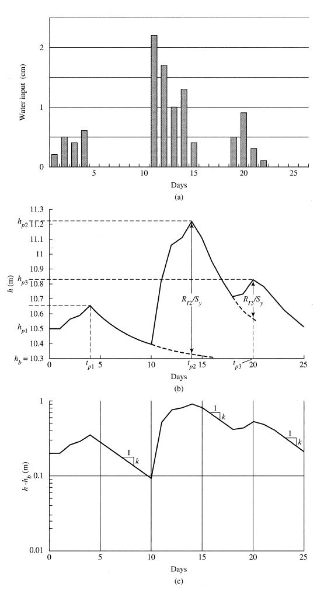

```python
# metadata
start_date = "2016-04-01"
end_date = "2016-06-15"
headers = ["USGS","site_no","datetime","depth [ft]","approval"]
site_no = "402512074414301"
# near the intersection of Blawenburg Belle Mead Rd. and Skillman Rd

# create url to load data from
url = f'https://waterservices.usgs.gov/nwis/dv/?format=rdb&sites={site_no}&startDT={start_date}&endDT={end_date}&siteStatus=all'
# read in the data and set headers
north_well = pd.read_csv(url, sep='\t', skiprows=29,header=None)
north_well.columns = headers
# Lat 40°25'12", long 74°41'43"

# set depth using altitude of well
# Land-surface datum is 110 ft above National Geodetic Vertical Datum of 1929
north_well['WT'] = 110 - north_well['depth [ft]']

# get rain from daymet using same start and end date as above
url = "https://daymet.ornl.gov/single-pixel/send/saveData?lat=40.3573&lon=-74.6672&start="+start_date+"&end="+end_date+"&format=csv"

# read in the data
weather = pd.read_csv(url, skiprows=6)
#print(weather.head())

# add the precip column from the weather dataframe to the north_well dataframe
# (keeping everything in one dataframe makes things easier down the road)
north_well['rain'] = weather['prcp (mm/day)']
north_well.head()
```

|  | USGS | site_no | datetime | depth [ft] | approval | WT | rain |
| --- | --- | --- | --- | --- | --- | --- | --- |
| 0 | USGS | 402512074414301 | 2016-04-01 | 14.81 | A | 95.19 | 2.59 |
| 1 | USGS | 402512074414301 | 2016-04-02 | 14.87 | A | 95.13 | 5.27 |
| 2 | USGS | 402512074414301 | 2016-04-03 | 15.26 | A | 94.74 | 0.00 |
| 3 | USGS | 402512074414301 | 2016-04-04 | 15.50 | A | 94.50 | 3.28 |
| 4 | USGS | 402512074414301 | 2016-04-05 | 15.94 | A | 94.06 | 0.00 |

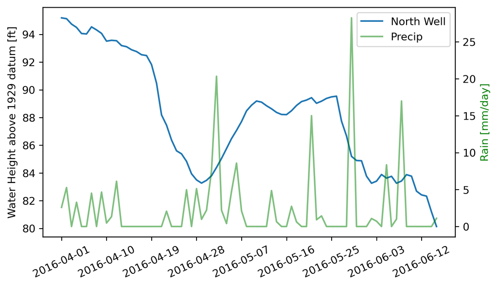

```python
# plot data
fig, ax = plt.subplots(figsize=(7,4), dpi=300)
well_series = ax.plot(north_well['datetime'], north_well['WT'], label = 'North Well')
ax.set_ylabel('Water Height above 1929 datum [ft]')

# twin axis
ax2 = ax.twinx()
rain_series = ax2.plot(north_well['datetime'], north_well['rain'], alpha=0.5, color='green',label = 'Precip')
ax2.set_ylabel('Rain [mm/day]', color='green')

# maxe xticks look nicer
ax.set_xticks(north_well['datetime'][::len(north_well['datetime']) // 8])
ax.tick_params(axis='x', labelrotation=25)

# make legends show up in one box for twin axis
all_series = well_series + rain_series
labels = [s.get_label() for s in all_series]
ax.legend(all_series, labels)
```

# Assignment

Below is the assignment for this HW. Please provide complete answers to each question using a Markdown box to clearly and completely answer each question. The questions provide the type of answer needed (e.g. text, code, numeric answer, graph) in addition to the number of points for each question. There's a lot of info on [Markdown Syntax](https://www.markdownguide.org/basic-syntax/) available on the web.

**Q1** *(10 pts, text)*

In deriving the Dupuit approximation for unconfined flow, we were able to write $K_{h,x}(x,y)=K_{h,y}(x,y)=K_h(x,y)=K_h$ by assuming that the flow was homogeneous and isotropic (i.e., the flow was *not* heterogeneous and *not* anisotropic).

1. What is the difference between heterogeneity and anisotropy?
2. Can groundwater flow be anisotropic yet homogeneous? Explain your answer.

`<Q1.1 Heterogeneity, unlike homogeneity, is the variations in aquifer properties, such as hydraulic conductivity, porosity, or storativity, from place to place within the aquifer. So, properities depend on the location in heterogenous aquifer.>`

`<Anisotropy is another term that means the directional differences in aquifer properties. One example is the difference in hydraulic conductivity in horizontal direction and vertical direction. While dupuit approximation solely focuses on the horizontal movement, anisotropy shows some difference of properties based on the direction, not specific like location.>`

`<Q1.2 Yes, I believe it is possible for the groundwater to be anisotropic and yet homogenous. If the aquifer has uniform material everywhere, for example some type of soil, it is considered as the homogenous. However, the flow properties can differ with direction due to subsurface sediment layering and other reasons. So, it can be anisotropic. Yes, groundwater flow can be anisotropic yet homogeneous. Homogeneity considers more about 3D spatial location (x,y,z), while anisotropy concerns about simply the directional variation (horizontal vs vertical vs z-direction).>`

**Q2** *(10 pts, text)*

Use the [ParFlow Sandtank](https://sandtank.hydroframe.org/) to answer the following questions about material properties:

1. How does changing the particle size (via the material properties sliders) affect the flow of water?
2. Inject 5 units of pollutant into Well A, and run the program under the following conditions, and comment on what you observe:
   1. Soil 1 is gravel, Soil 2 is loam, Soil 3 is sand, Soil 4 is clay (should be default conditions)
   2. Reset the model. Same as 2.A, but change Soil 1 to clay
   3. Reset the model. Same as 2.B, but change Soil 4 to gravel

`<Q2.1 On ParFlow Sandtank, changing particle size affects the variable K, the hydraulic conductivity, of Dracy's law that calculates the flow of water within the subsurface. For example, larger particles (gravel) have higher hydraulic conductivity, aloowing water to move faster. Smaller particles (like clay) slow water flow due to its lower hydraulic conducitivity. The flow generally becomes gradually slower changing the property one by one from gravel, soil to clay. On Sandtank, it is visible in how fast the water level inside the wells change depending on the material properties>`

`<Q2.2>`

`<A. With default soils (Gravel-Loam-Sand-Clay), water table rises and drops quickly back as it is right now at the gravel with high hydraulic conductivity. Pollutant injected alongside water from Well A spreads in both horizontal and vertical direction but do not transfer into other soils as it seems to be domainated by the loam. It also does not penetrate uniformly into all soils because the subsurface is heterogeneous rather than perfectly layered homogenous.>`

`<B. I believe due to changing Soil 1 to be clay, we now have two clay soils. So, even though the diagram is showing loam around the well, there is more presence of clay and it slows down the movement, limiting the pollutant released to move mainly horizontally, with barely any vertical movement. Horizontal water table / head movement seemed a bit slower compared to having Soil 1 as gravel.>`

`<C. If Soil 4 is changed to gravel, new downward permeability path is created so pollutant is spreading mostly downward, widely, resembling plant's wide root system. Vertical movement starts being active because of enhanced conductivity>`

**Q3** *(20 pts, text)*

The appropriate recession formula to use is here: $$ h=h_b+(h_0-h_b)\text{exp}(-c t) $$ where $c$ is a positive value found as the negative slope of $(\text{log}(h-h_b))/(\text{time [days]})$ and $h_0$ is the head value at which the recession begins.

Your answer should:

1. Correctly calculate **and print** the value of $c$
2. Have three plots:
   1. Plot of North Well head data minus baseflow (defined as $h-h_b$) against datetime, with the y-axis in logarithmic units
   2. Plot of your North Well head model, as well as the original water table data (defined as $h$), against datetime. Both axes should be in linear units
   3. Plot of your North Well head model forecasted into the future for a long time (~50 days) to capture the recession (not considering recharge), as well as the North Well water table data (defined as $h$), against time. Both axes should be in linear units.
3. Use the text cell to comment on the differences between the model and the data, and any other observations you observe. Why do you think these differences occur?

To guide you, a skeleton code has been given to you.

```python
# loading in data - don't need to change anything in this cell (but make sure you understand it)
# but feel free to uncomment print statements to check out the data

# metadata, url, and loading data (same as above)
start_date = "2016-04-18"
end_date = "2016-04-24"
headers = ["USGS","site_no","datetime","depth [ft]","approval"]
site_no = "402512074414301"
url = f'https://waterservices.usgs.gov/nwis/dv/?format=rdb&sites={site_no}&startDT={start_date}&endDT={end_date}&siteStatus=all'
north_well = pd.read_csv(url, sep='\t', skiprows=29,header=None)
north_well.columns = headers
# Lat 40°25'12", long 74°41'43"
#print(url)

# set depth using altitude of well
# Land-surface datum is 110 ft above National Geodetic Vertical Datum of 1929
north_well['WT'] = 110 - north_well['depth [ft]']

# get rain from daymet using same start and end date as above, but you do not need to use it
url = "https://daymet.ornl.gov/single-pixel/send/saveData?lat=40.3573&lon=-74.6672&start="+start_date+"&end="+end_date+"&format=csv"
weather = pd.read_csv(url, skiprows=6)

# add the precip column from the weather dataframe to the north_well dataframe
# (keeping everything in one dataframe makes things easier down the road)
north_well['rain'] = weather['prcp (mm/day)']
north_well#.head()
```

|  | USGS | site_no | datetime | depth [ft] | approval | WT | rain |
| --- | --- | --- | --- | --- | --- | --- | --- |
| 0 | USGS | 402512074414301 | 2016-04-18 | 17.53 | A | 92.47 | 0.00 |
| 1 | USGS | 402512074414301 | 2016-04-19 | 18.18 | A | 91.82 | 0.00 |
| 2 | USGS | 402512074414301 | 2016-04-20 | 19.52 | A | 90.48 | 0.00 |
| 3 | USGS | 402512074414301 | 2016-04-21 | 21.81 | A | 88.19 | 0.00 |
| 4 | USGS | 402512074414301 | 2016-04-22 | 22.55 | A | 87.45 | 2.07 |
| 5 | USGS | 402512074414301 | 2016-04-23 | 23.62 | A | 86.38 | 0.00 |
| 6 | USGS | 402512074414301 | 2016-04-24 | 24.40 | A | 85.60 | 0.00 |

```
7
```

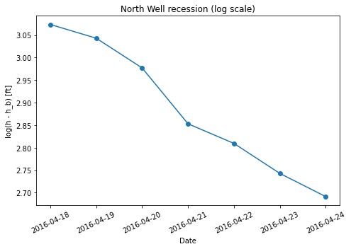

```
Calculated c (inverse of residence time): 0.0684 per day
```

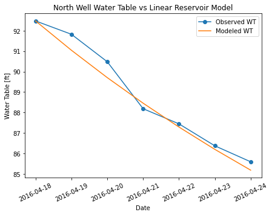

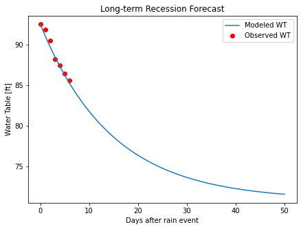

```python
# define h_b as the minimum water table head from 2014 - 2018 [ft]
h_b = 70.85

# get the number of days in dataframe
no_of_days = len(north_well.index)
print(no_of_days)

### your code below here ###

# STEP 1: Use h_b to make a column h - h_b
# and convert the column of north_well head to logarithmic units and plot

north_well['h_minus_hb'] = north_well['WT'] - h_b

plt.figure(figsize=(7,5))
plt.plot(pd.to_datetime(north_well['datetime']), np.log(north_well['h_minus_hb']), marker='o')
plt.ylabel('log(h - h_b) [ft]')
plt.xlabel('Date')
plt.title('North Well recession (log scale)')
plt.xticks(rotation=25)
plt.tight_layout()
plt.show()



#So, here I plotted the actual drainage graph using the observed data. Doing it with np.log can clearly show the decrease trend.
#Now Step 2 is having a best fit line for my first plot and finding the slope, which is c.

# STEP 2: Calculate c and print the value with units
# be sure to define h_0 from the dataframe
# and make sure to print the value of c

t_days = np.arange(len(north_well))  # 0 to 6, so total 7 days
ln_h_diff = np.log(north_well['h_minus_hb']) #using this to make it a linearized straight line

#Finding slope of the best fit line as python is capable for doing it through np.polyfit automatically
slope, intercept = np.polyfit(t_days, ln_h_diff, 1)
c = -slope  # positive
print(f'Calculated c (inverse of residence time): {c:.4f} per day')


# STEP 3: Create a function to model this decrease.
# A time axis has been created for you

# create time axis in days
h_0 = north_well['WT'].iloc[0]  # 110-17.53 ft 's one as the initial for our model.
h_model = h_b + (h_0 - h_b) * np.exp(-c*t_days)

#Now I am plugging the c value back to the formula given which gives me the smooth exponential decay.

# STEP 4: Plot your model over the original data (not in logspace), and comment on any differences

plt.figure(figsize=(7,5))
plt.plot(pd.to_datetime(north_well['datetime']), north_well['WT'], marker='o', label='Observed WT')
plt.plot(pd.to_datetime(north_well['datetime']), h_model, label='Modeled WT')
plt.xlabel('Date')
plt.ylabel('Water Table [ft]')
plt.title('North Well Water Table vs Linear Reservoir Model')
plt.legend()
plt.xticks(rotation=25)
plt.show()

#While the general trend is matching, there seems to be certain small differences that the model cannot capture.


# STEP 5: Plot the model for a long time (say, 7 weeks) to examine the drainage behavior as if no rain had fallen
# plot it on top of the original data (you will need to use two different time axes)
# for this plot, you do not need to have the dates on the x-axis, number of days after rain event is fine

# create new time axis in days. So, here I am doing for 50 days using 100 points for smoothness.
t_long = np.linspace(0,50,100)

h_long = h_b + (h_0 - h_b) * np.exp(-c*t_long)

plt.figure(figsize=(7,5))
plt.plot(t_long, h_long, label='Modeled WT')
plt.scatter(t_days, north_well['WT'], color='red', label='Observed WT')
plt.xlabel('Days after rain event')
plt.ylabel('Water Table [ft]')
plt.title('Long-term Recession Forecast')
plt.legend()
plt.show()
```

`<Q3.3 The linear reservoir model is capturing the overall trend of the exponential decline of the water table after the rain event. However, the observed data fluctuates slightly above and below the model's best fit line on some days. These differences can occur because of heterogeneity in soil properities, or model not accounting for some short-term rainfall (2.07 mm on Apr 22) that is happening. Overall, I think model can provide a reasonable and accurate first approximation of the subsurface behavior.>`

**Q4** *(20 pts, code, plot)*